# Incarceration

Haruon Salah

08/01/2023

### Summary Information

- The average value of my variable across first 5 counties of Alabama is:

494.9493

- The highest total jail population across first 5 counties of alabama is:

2018 Barbour County 702.18

- The lowest total jail population across first 5 counties of alabama is:

2010 Blount County 332.87

- The change in total population among the first 5 counties of Alabama in Last 5 Years is:

Year Avg Change 2015 501.320 27.906 2016 492.250 11.208 2017 498.138 5.564 2018 511.900 9.042

### The Dataset

#### Who collected the data?

In December 2015, Vera released the Incarceration Trends data tool (trends.vera.org) and the companion publication In Our Own Backyard: Confronting Growth and Disparities in American Jails. This work employed two Bureau of Justice Statistics (BJS) data collections: the Census of Jails (COJ), which covers all jails and is conducted every five to eight years since 1970, and the Annual Survey of Jails (ASJ), which covers about one-third of jails—and includes nearly all of the largest jails—that has been conducted in non-census years since 1982. This project was funded by the Robert W. Wilson Charitable Trust.

#### How was the data collected or generated?

This dataset was assembled using information collected by the U.S. Department of Justice Bureau of Justice Statistics (BJS), supplemented with data from state departments of correction when federal data is not available.

#### Why was the data collected?

The potential reasons for collecting this data include:

- Public Safety and Crime Prevention
- Policy Development and Evaluation
- Criminal Justice Reform
- National and State Reporting
- Public Awareness

#### How many features (columns) are in the data?

There are 4 columns in my dataset.

#### What, if any, ethical questions or questions of power do you need to consider when working with this data?

- Privacy and Confidentiality
- Informed Consent
- Data Use and Misuse
- Long-term Effects of Incarceration
- Data Transparency
- Data Bias and Fairness

#### What are possible limitations or problems with this data?

The possible limitations of this data are:

The population rates for jails and prisons in various counties and states are shown in detail in the dataset under consideration. But like every dataset, it has some restrictions that must be recognized and taken into account when interpreting the results. The procedure for gathering data and reporting is one potential drawback. The dataset may become inconsistent due to differences in reporting procedures between jurisdictions, which could result in disparities in the accuracy and completeness of the information provided. The dataset may also be biased by the data and not be representative. Skewed depictions of the genuine prison population can be caused by elements including different approaches to law enforcement, reporting procedures, and regional demographic differences.

### Trends Over Time Chart

To see the trends over time changes in the total jail population rate, I’ve embedded a trends over time chart below. Let’s see the patterns on the graph. It is clearly shows that, there is a increase in jail population rate of Barbour County and Bib county. Whereas, for Blount County and Autuagu County they are mostly steady at the same rate. Also there is a high decrease in jail population of Baldwin county during 2013 - 2018.

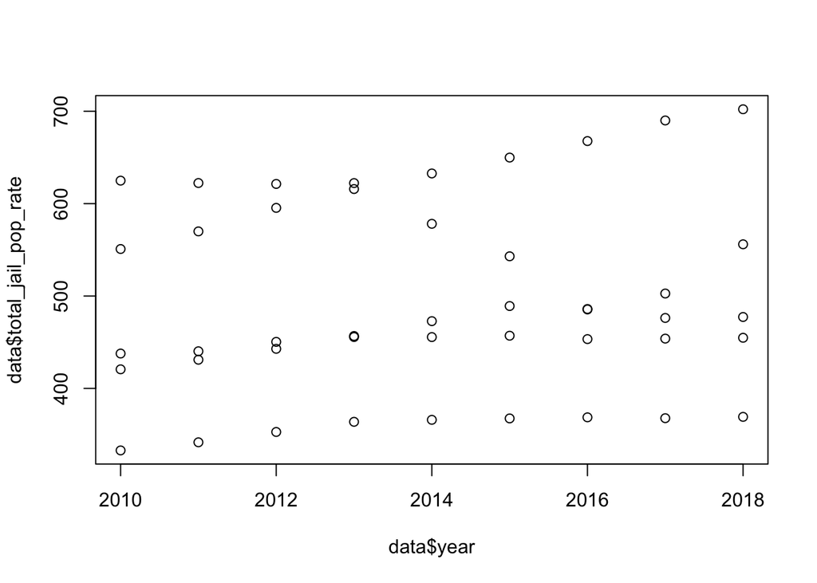

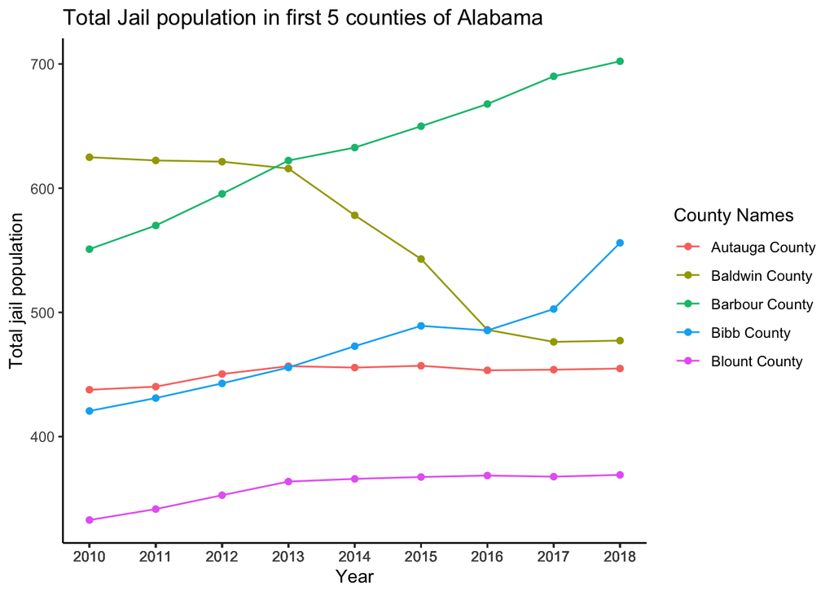

### Variable Comparison Chart

To compare two variables, I’ve chose Autauga County and Baldwin County jail population into a bar chart embedded below. It is clearly shown that, there is a slight increase in the jail population of Autauga County where as a remarkable decrease in the jail population Baldwin County.

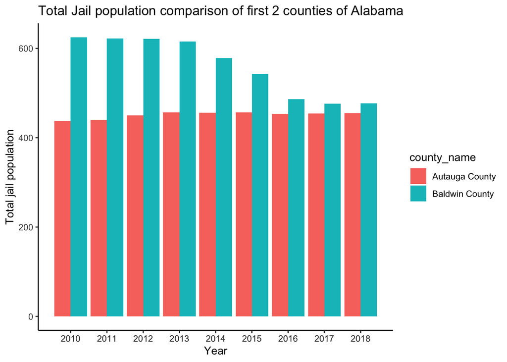

### Map

To display the total population estimates in different Counties of Alabama, I’ve embedded a map to shown variable total population distribution geographically. The area marked with the darkest color shows the highest population estimate while the lightest area shows the lowest population estimate in that area.

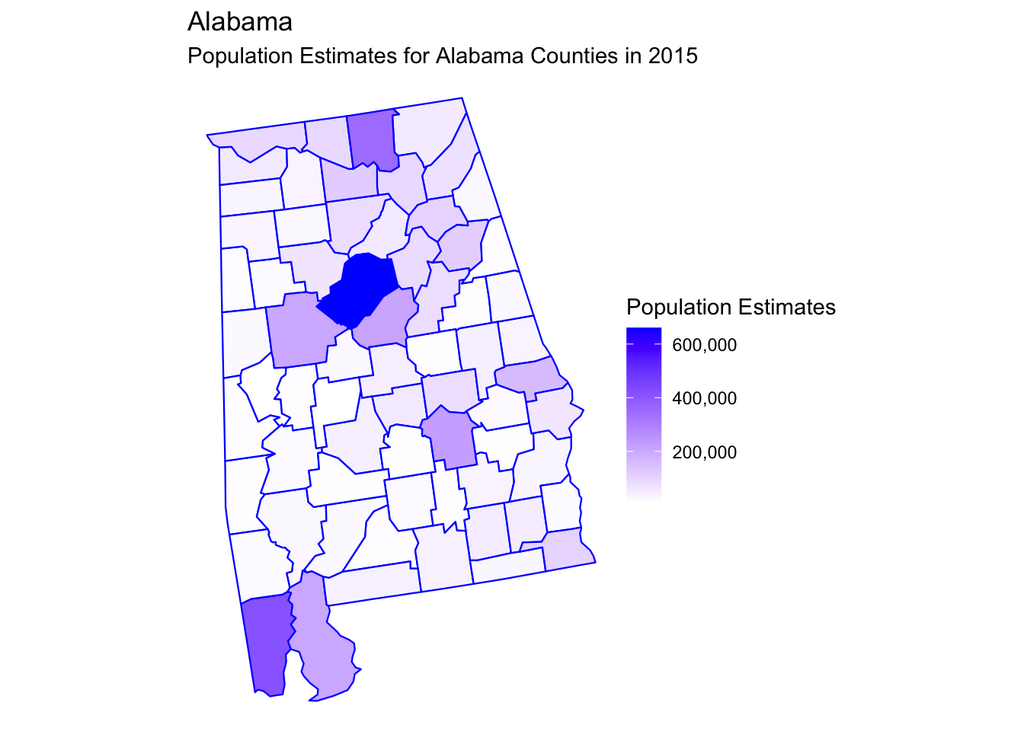